# Machine Learning for Lifespan Prediction using California Teaching Study (CTS) Data

## Overview

This Jupyter Notebook explores the application of machine learning and deep learning techniques to predict human lifespan based on diet and smoking habits using data from the California Teaching Study. Each code cell is dedicated to specific tasks, ranging from data ingestion to model evaluation.

## Workflow

### 1. Data Loading and Preprocessing

In this section, we prepare our dataset for the regression models. The code is designed to load the data, assuming it's located in the same directory as the notebook. The processing of data include selecting features related to Diet and Smoking being asked in the first questionare.

### 2. Model Building

#### 2.1 XGBoost Regression Model

Here, we introduce the XGBoost regression model to predict the expected lifespan of participants based on their diet and smoking habits. The dataset will be split into training and testing sets. The features are scaled using the `StandardScaler` to ensure uniformity in input values. Scaling features ensures that all input variables have a similar scale, which can lead to better and faster convergence during model training, and helps in preventing any single feature from disproportionately influencing the model's predictions.

#### 2.2 Deep Learning Regression Model

In this subsection, a Deep Learning model is constructed and trained to predict lifespan using the same features. The model architecture refers to the overall design and structure of the neural network, defining how the input data flows through various interconnected layers. The layer details pertain to the specifics of each layer in the network, such as the type of layer (e.g., dense, convolutional), number of neurons or nodes, and activation functions used. Training epochs are defined as one complete forward and backward pass of all the training examples through the model. In other words, it represents a single cycle through the entire dataset. Models typically require multiple epochs for training to effectively learn and adjust their weights based on the entire dataset. Layer details and training epochs are essential for deep learning models, as they determine the model's complexity and the depth of its learning, respectively.

## Instructions

Before diving into the content, ensure you have all the necessary libraries installed and the data files are present in the specified directory. Following that, run each cell in sequence.

#### Note:

This notebook assumes the data files to be housed in the same directory as the notebook. If this isn't the case in your setup, ensure to adjust the file paths in the code accordingly.

#### Importing Necessary Packages and select random seed

```python
import pandas as pd
import random
import numpy as np
from sklearn.preprocessing import OneHotEncoder
import xgboost as xgb
from sklearn.model_selection import train_test_split
from sklearn.metrics import mean_absolute_error
import matplotlib.pyplot as plt
import shap
from sklearn.cluster import KMeans
from sklearn.preprocessing import StandardScaler
from sklearn.decomposition import PCA
from sklearn.linear_model import ElasticNet
import torch
import torch.nn as nn
import torch.optim as optim
from torch.optim.lr_scheduler import StepLR
from sklearn.ensemble import RandomForestRegressor
from sklearn.manifold import TSNE
random.seed(48)
```

#### Loading the Survey data

```python
survey_df=pd.read_csv("surveydata_ai_ml.csv", encoding='unicode_escape', low_memory=False)
survey_df.shape
```

```
(125120, 1229)
```

#### Loading the Core data

```python
core_df=pd.read_csv("oshpd_core_processed1.csv", encoding='unicode_escape', low_memory=False)
core_df.shape
```

```
(331528, 26)
```

#### Removing duplicated patients:

We remove duplicated participants from the data to ensure there is no leakage in the prediction model. Leakage, in the context of machine learning, refers to the unintentional introduction of information from the test dataset into the training dataset, which can lead to overly optimistic performance evaluations. This happens when the model inadvertently gains access to the target values from the test set during training. By removing duplicates – identified by participant_key, we ensure that each participant's data is represented only once. This step is crucial because leakage can result in a model that appears to perform exceptionally well on known data but fails to generalize to new, unseen data. By eliminating the possibility of leakage, we aim to build a more robust and reliable prediction model.

```python
core_df=core_df.drop_duplicates(subset=['participant_key'])
core_df.shape
```

```
(89773, 26)
```

#### Looking at the list of the columns in the Core dataframe:

Let's briefly look at the columns available in the core data.

```python
print(core_df.columns.tolist())
```

```
['participant_key', 'date_of_birth_dt', 'date_of_death_dt', 'cause_of_death_cde', 'qnr_1_fill_dt', 'qnr_2_fill_dt', 'qnr_3_fill_dt', 'qnr_4_fill_dt', 'qnr_5_fill_dt', 'qnr_6_fill_dt', 'admission_dt', 'discharge_dt', 'admission_typ', 'admission_value', 'length_of_stay_day_cnt', 'src_admission_cde', '…
```

#### Looking at the list of the columns in the Survey dataframe:

Let's briefly look at the columns available in the survey data just to get to know what is available.

```python
print(survey_df.columns.tolist())
```

```
['participant_key', 'date_of_birth_dt', 'date_of_death_dt', 'cause_of_death_cde', 'cause_of_death_dsc', 'qnr_1_fill_dt', 'qnr_2_fill_dt', 'qnr_3_fill_dt', 'qnr_4_fill_dt', 'qnr_4_mini_fill_dt', 'qnr_5_fill_dt', 'qnr_5_mini_fill_dt', 'qnr_6_fill_dt', 'ses_quartile_ind', 'blockgroup90_urban_cat', 'hys…
```

#### Develop a helper function to calculate life span in years

This function uses date of death and date of birth to calculate life span of patients.

```python
def find_length_life(df):
    df['date_of_birth_dt'] = pd.to_datetime(df['date_of_birth_dt'])
    df['date_of_death_dt'] = pd.to_datetime(df['date_of_death_dt'])
    df['life_years'] = (df['date_of_death_dt'] - df['date_of_birth_dt']).dt.days / 365
    df = df.dropna(subset=['life_years'])
    df = df.drop(['date_of_birth_dt', 'date_of_death_dt'], axis=1)
    return(df)
```

```python
core_df=find_length_life(core_df)
```

#### Plot the distribution of Life Span in years

Here we visuzlize the distribution of Life Span across all the participants with available Life Span information. The distribution plot shown bellow, reveals the mean and meadin life span of 83.4 and 85.5 years respectively.

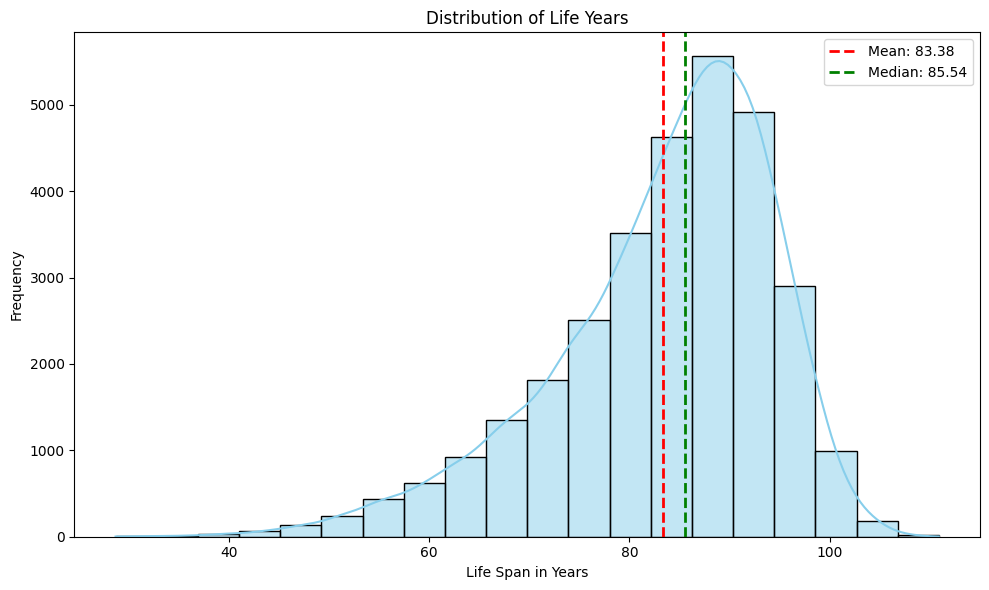

```python
import matplotlib.pyplot as plt
import seaborn as sns

# Assuming you have imported the necessary libraries and loaded your data as core_df

# Set up the figure and axes
plt.figure(figsize=(10, 6))
ax = plt.gca()

# Customize the histogram using Seaborn
sns.histplot(data=core_df, x='life_years', bins=20, kde=True, color='skyblue', edgecolor='black', ax=ax)

# Calculate mean and median
mean_life_years = core_df['life_years'].mean()
median_life_years = core_df['life_years'].median()

# Add labels and title
plt.xlabel('Life Span in Years')
plt.ylabel('Frequency')
plt.title('Distribution of Life Years')

# Annotate mean and median on the plot
plt.axvline(mean_life_years, color='red', linestyle='dashed', linewidth=2, label=f'Mean: {mean_life_years:.2f}')
plt.axvline(median_life_years, color='green', linestyle='dashed', linewidth=2, label=f'Median: {median_life_years:.2f}')

# Show the legend
plt.legend()

# Show the plot
plt.tight_layout()
plt.show()
```

### Data Processing

Data processing involves data cleaning and preparing data into a proper numerical format for the downstream Machine Learning analysis.

##### Step1

We removed columns with more than 50% missing values

##### Step2

If a column is numerical, we keep it as is. If a column is not numerical, then we do one-hot encoding. To do one-hot encoding, each categorical feature will be translated into four new binary columns, 3 of columns are the top 3 categories and the 4th column is all other categories named as 'others'. We chose three categories for simplicity and to avoid having high dimensional data.

```python
def process_df(df):
    # Drop columns with more than 50% missing values
    threshold = len(df) * 0.50
    df = df.dropna(axis=1, thresh=threshold)

    # Function to process each column
    def process_column(col):
        if np.issubdtype(col.dtype, np.number):  # If column is numeric, keep it as is
            return col
        else:  # If column is not numeric, perform one-hot encoding
            top_3_categories = col.value_counts().nlargest(3).index
            col = col.apply(lambda x: x if x in top_3_categories else 'other')
            one_hot_encoder = OneHotEncoder(sparse=False, dtype=int)
            one_hot_encoded = one_hot_encoder.fit_transform(col.to_numpy().reshape(-1, 1))
            encoded_df = pd.DataFrame(one_hot_encoded, columns=one_hot_encoder.get_feature_names_out([col.name]))
            return encoded_df

    # Apply the process_column function to each column and concatenate the resulting DataFrames
    processed_columns = [process_column(df[col]) for col in df.columns]
    processed_df = pd.concat(processed_columns, axis=1)
    return(processed_df)
```

### Process the core and survey data and combine them into a single table

We first process the core and survey data based on the crieria explained above and then merge them into a single cleaned-up table with each row representing each participants and its features and life span.

```python
core_df_processed=process_df(core_df)
survey_df_processed=process_df(survey_df)
full_df = pd.merge(survey_df_processed, core_df_processed, on='participant_key', how='inner')
print(full_df.shape)
```

```
(30869, 1587)
```

### Selection of Model Features

```python
##################### Diet:

# Assuming your dataframe is called 'full_df'
columns_to_keep = ['diet', 'daily', 'life_years', 'smoke']
columns_to_drop = ['participant_key','age','age_at_baseline',
                   'q2', 'q3', 'q4', 'q5', 'q6','dt','date',
                   '_daily_', '_lifeexpo','diet_analyselig']


cols_keep = [col for col in full_df.columns if any(substr in col for substr in columns_to_keep)]
cols_drop = [col for col in cols_keep if any(substr in col for substr in columns_to_drop)]

full_df_dietsmoke = full_df[cols_keep].drop(columns=cols_drop)
full_df_dietsmoke = full_df_dietsmoke.replace([np.inf, -np.inf], np.nan)
full_df_dietsmoke = full_df_dietsmoke.dropna()

print(full_df_dietsmoke.shape)
```

```
(18071, 22)
```

```python
X = full_df_dietsmoke.drop('life_years', axis=1)
y = full_df_dietsmoke['life_years']
print("=====================")
print(X.shape)
print("=====================")
```

```
=====================
(18071, 21)
=====================
```

### Data Visualization

Although the data has 21 features (21 dimensions), we use PCA (Principal Component Analysis) to reduce the dimensionality and visualize the entire dataset in 2 dimensions. PCA is a statistical technique that identifies patterns in data based on the correlation between features. By transforming the original data into a new coordinate system, PCA captures the most significant variances in the data with fewer dimensions, making it easier to visualize.

The reason we visualize the data in 2 dimensions is that human vision and most plotting tools are limited to two or three dimensions. By mapping our 21-dimensional data down to just 2 dimensions using PCA, we can get a visual representation that gives us insight into data groupings, separations, and potential patterns.

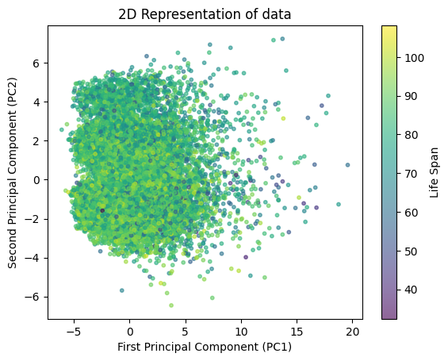

```python
# Scale the features
scaler = StandardScaler()
X_scaled = scaler.fit_transform(X)

# Apply K-means clustering
kmeans = KMeans(n_clusters=10, random_state=42)
clusters = kmeans.fit_predict(X_scaled)

# Visualize the clusters (Optional)
# Reduce dimensions to 2D using PCA
pca = PCA(n_components=2)
X_pca = pca.fit_transform(X_scaled)

plt.scatter(X_pca[:, 0], X_pca[:, 1], c=y, cmap='viridis', s=10, alpha=0.6)
plt.colorbar(label='Life Span')
plt.xlabel("First Principal Component (PC1)")
plt.ylabel("Second Principal Component (PC2)")
plt.title('2D Representation of data')
plt.show()
```

In this plot, each point corresponds to a data instance, and the spatial relationships between the points approximate the relationships in the 21-dimensional space. Points that are closer together in this plot were likely close in the original space, indicating similar feature values. This visualization helps in identifying clusters or groups of similar data instances and any potential outliers.

## Machine Learning Modeling

### 1) Best Prediction Without Any Features

```
Mean Train MAE: 8.421467017166412, Mean Test MAE: 8.366814514056916
```

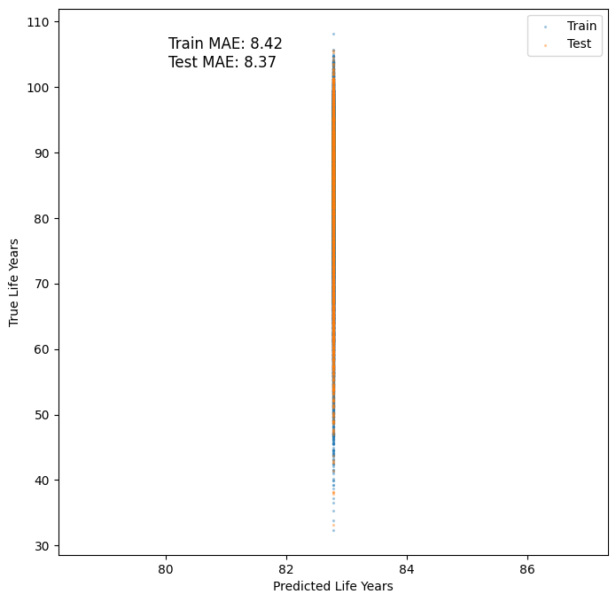

```python
####################################################################################
####################################################################################
##################### Model = Average
# Train-test split
X_train, X_test, y_train, y_test = train_test_split(X, y, test_size=0.2, random_state=42)

# Calculate the mean of the training set labels
mean_train_label = y_train.mean()

# Predict the mean value for both the training and test sets
y_train_mean_pred = [mean_train_label] * len(y_train)
y_test_mean_pred = [mean_train_label] * len(y_test)

# Calculate the MAE for the mean prediction on train and test sets
mean_train_mae = mean_absolute_error(y_train, y_train_mean_pred)
mean_test_mae = mean_absolute_error(y_test, y_test_mean_pred)

print(f"Mean Train MAE: {mean_train_mae}, Mean Test MAE: {mean_test_mae}")

#print(f"Train MAE: {train_mae}, Test MAE: {test_mae}")

# Plot the true vs predicted life_years for train and test sets
plt.figure(figsize=(8, 8))
plt.scatter(y_train_mean_pred, y_train, label='Train', alpha=0.3,s=2)
plt.scatter(y_test_mean_pred, y_test, label='Test', alpha=0.3,s=2)
plt.ylabel('True Life Years')
plt.xlabel('Predicted Life Years')
plt.legend()

# Add MAE values for train and test to the plot
mae_text = f"Train MAE: {mean_train_mae:.2f}\nTest MAE: {mean_test_mae:.2f}"
plt.text(0.2, 0.95, mae_text, transform=plt.gca().transAxes, fontsize=12, verticalalignment='top')
plt.show()

####################################################################################
####################################################################################
mean_test_mae_random_guess=mean_test_mae
```

```python
data_dict={'daily_fiber': '71-82. Daily Dietary Fiber (grams). From the first CTS questionnaire (1995-1996).',
          'daily_prot':'71-82. Daily Dietary Protein. From the first CTS questionnaire (1995-1996).',
          'daily_fat':'71-82. Daily Dietary Fat. From the first CTS questionnaire (1995-1996).',
          'daily_calcium':'71-82. Daily Dietary Calcium. From the first CTS questionnaire (1995-1996).',
          'daily_sfat':'71-82. Daily Dietary Saturated Fat. From the first CTS questionnaire (1995-1996).',
          'daily_oleic':'71-82. Daily Dietary Oleic Acid. From the first CTS questionnaire (1995-1996).',
          'daily_lino':'71-82. Daily Dietary Linoleic Acid. From the first CTS questionnaire (1995-1996).',
          'daily_chol':'71-82. Daily Cholesterol. From the first CTS questionnaire (1995-1996).',
          'daily_folate':'71-82. Daily Dietary Folate. From the first CTS questionnaire (1995-1996).',
          'totdiet_caroten':'71-82. Dietary total carotenoids. From the first CTS questionnaire (1995-1996).',
          'totdaily_kcal':'71-82. Total daily caloric intake. From the first CTS questionnaire (1995-1996).',
          'totdaily_carb':'71-82. Total grams per day of carbohydrate intake. From the first CTS questionnaire (1995-1996).',
          'glyc_avgdaily':'71-82. Average daily glycemic index (white bread as ref), glycloadwb/dt_carbs (without fiber). From the first CTS questionnaire (1995-1996).',
          'diet_plant':'71-82. Diet pattern - factor score for plant-based pattern. From the first CTS questionnaire (1995-1996).',
          'diet_highprotfat':'71-82. Diet pattern - factor score for high protein/fat pattern. From the first CTS questionnaire (1995-1996).',
          'diet_highcarb':'71-82. Diet pattern - factor score for high carb pattern. From the first CTS questionnaire (1995-1996).',
          'diet_saladwine':'71-82. Diet pattern - factor score for salad and wine pattern. From the first CTS questionnaire (1995-1996).',
          'smoke_group':'84-88. Smoking group. From the first CTS questionnaire (1995-1996).',
          'smoke_statcat':'84. Smoking status categories. From the first CTS questionnaire (1995-1996).',
          'smoke_expocat':'84, 87, 88. Smoking exposure categories. From the first CTS questionnaire (1995-1996).',
          'smoke_1stpreg':'2, 28, 84, 85. Smoking in relation to first pregnancy categories. From the first CTS questionnaire (1995-1996).'}
```

#### 2) XGboost Model

XGBoost, which stands for eXtreme Gradient Boosting, is an optimized distributed gradient boosting library designed to be highly efficient, flexible, and portable. It stands out for its capacity to perform well on a wide range of datasets, often delivering top-tier results on many machine learning challenges. Built upon the principles of gradient boosting, XGBoost implements the algorithm in a parallelized way, allowing for faster performance. Moreover, it offers several advanced features, including regularization for better generalization, tree pruning, and handling of missing data, making it a preferred choice for many data scientists in both regression and classification tasks.

```
Train MAE: 4.558771223793851, Test MAE: 7.507490012681814
```

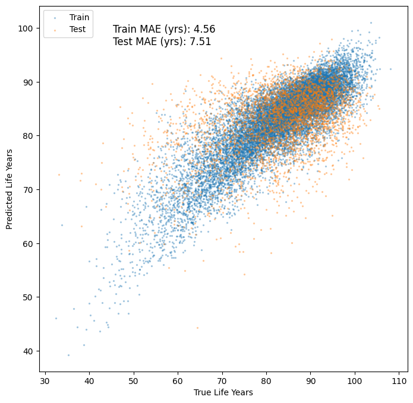

```python
# Train-test split
X_train, X_test, y_train, y_test = train_test_split(X, y, test_size=0.2, random_state=42)

# Scale the features
scaler = StandardScaler()
X_train = scaler.fit_transform(X_train)
X_test = scaler.transform(X_test)

# Train the XGBoost model
model = xgb.XGBRegressor(objective='reg:squarederror')
model.fit(X_train, y_train)

# Predict on train and test sets
y_train_pred = model.predict(X_train)
y_test_pred = model.predict(X_test)

# Calculate the MAE for train and test sets
train_mae = mean_absolute_error(y_train, y_train_pred)
test_mae = mean_absolute_error(y_test, y_test_pred)

print(f"Train MAE: {train_mae}, Test MAE: {test_mae}")

# Plot the true vs predicted life_years for train and test sets
plt.figure(figsize=(8, 8))
plt.scatter(y_train, y_train_pred, label='Train', alpha=0.3, s=2)
plt.scatter(y_test, y_test_pred, label='Test', alpha=0.3, s=2)
plt.xlabel('True Life Years')
plt.ylabel('Predicted Life Years')
plt.legend()

####################################################################################
# Add MAE values for train and test to the plot
mae_text = f"Train MAE (yrs): {train_mae:.2f}\nTest MAE (yrs): {test_mae:.2f}"
plt.text(0.2, 0.95, mae_text, transform=plt.gca().transAxes, fontsize=12, verticalalignment='top')
plt.show()
####################################################################################
####################################################################################
mean_test_mae_xgboost=test_mae
```

After the model training is done, above, we demonstrated model predictions of Life Span (in years) againts the True values for both training data and test data. We have shown that the XGboost model has the error of 7.51 years in predicting the Life Span.

### Model Interpretation:

Shapley Values and the Shapley Plot: Grounded in game theory, the Shapley Values and their corresponding Shapley plots offer insights into feature importance and their relationships in predictive modeling. From our Shapley plot, it's evident that Smoking_group is the paramount feature in predicting lifespan, succeeded by daily_prot, total_diet_caroten, and totdaily_kcal.

Beyond the hierarchical importance which diminishes from top to bottom, the plot's color scheme—red and blue—illuminates the directionality of feature impact. For instance, the plot suggests a clear negative correlation between smoking exposure and life expectancy: the absence of smoking results in a higher predicted lifespan. Similarly, high consumption of daily protein, elevated daily caloric intake, and a carbohydrate-rich diet are associated with a reduced lifespan. Conversely, diets that are abundant in salad and wine, as well as those with a balance of high protein and fat, appear to promote longer life expectancy.

```
ntree_limit is deprecated, use `iteration_range` or model slicing instead.
```

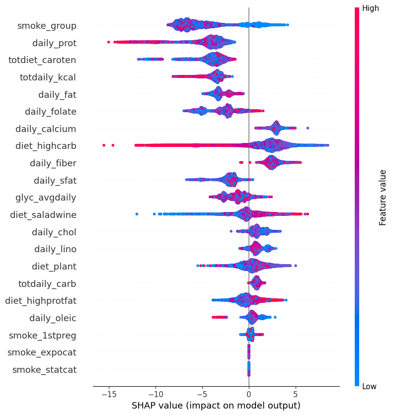

```python
# Compute SHAP values
explainer = shap.Explainer(model)
shap_values = explainer(X)

# Plot SHAP values
shap.plots.beeswarm(shap_values, max_display=100)
####################################################################################
```

#### 3) Deep Neural Network Models

##### Mean Absolute Error Plot

After training our deep neural network, we visualized its performance by plotting the Mean Absolute Error (MAE) against the epoch number for both training and test datasets. The x-axis represents the epoch number, while the y-axis represents the MAE. As epochs increase, the model's MAE ideally decreases, showing improvement in prediction accuracy. Two lines on the chart depict the MAE trends for both training and test data. A widening gap between these lines might indicate overfitting, where the model excels on training data but struggles with new, unseen data.

```
Epoch 9999: Train MAE: 7.12, Test MAE: 7.12, Learning Rate: 0.0001
```

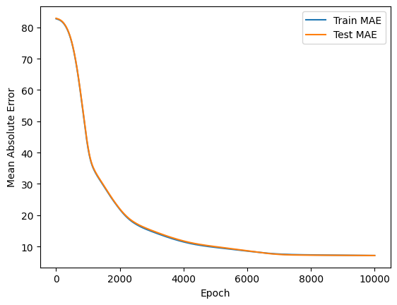

```python
X_train, X_test, y_train, y_test = train_test_split(X, y, test_size=0.2, random_state=42)

# Scale the features
scaler = StandardScaler()
X_train = scaler.fit_transform(X_train)
X_test = scaler.transform(X_test)

# Convert to PyTorch tensors
X_train_tensor = torch.FloatTensor(X_train)
y_train_tensor = torch.FloatTensor(y_train.values).view(-1, 1)
X_test_tensor = torch.FloatTensor(X_test)
y_test_tensor = torch.FloatTensor(y_test.values).view(-1, 1)

# Define the neural network model
class Net(nn.Module):
    def __init__(self):
        super(Net, self).__init__()
        self.fc1 = nn.Linear(21, 64)
        self.fc2 = nn.Linear(64, 32)
        self.fc3 = nn.Linear(32, 1)

    def forward(self, x):
        x = torch.relu(self.fc1(x))
        x = torch.relu(self.fc2(x))
        x = self.fc3(x)
        return x

model = Net()

# Loss and optimizer
loss_function = nn.L1Loss()  # Mean Absolute Error loss
optimizer = optim.Adam(model.parameters(), lr=0.0001)

# Learning rate scheduler
scheduler = StepLR(optimizer, step_size=100, gamma=1)

# Training the model
epochs = 10000
train_mae_values = []
test_mae_values = []

for epoch in range(epochs):
    # Forward pass
    y_pred = model(X_train_tensor)

    # Compute loss
    loss = loss_function(y_pred, y_train_tensor)

    # Zero gradients, backward pass, update weights
    optimizer.zero_grad()
    loss.backward()
    optimizer.step()

    # Step the scheduler
    scheduler.step()

    # Calculate and store MAE for train and test
    with torch.no_grad():
        train_mae = loss_function(model(X_train_tensor), y_train_tensor)
        test_mae = loss_function(model(X_test_tensor), y_test_tensor)
        train_mae_values.append(train_mae.item())
        test_mae_values.append(test_mae.item())

print(f"Epoch {epoch}: Train MAE: {train_mae:.2f}, Test MAE: {test_mae:.2f}, Learning Rate: {scheduler.get_last_lr()[0]}")

# Plot train and test MAE
plt.plot(range(epochs), train_mae_values, label="Train MAE")
plt.plot(range(epochs), test_mae_values, label="Test MAE")
plt.xlabel("Epoch")
plt.ylabel("Mean Absolute Error")
plt.legend()
plt.show()
####################################################################################
####################################################################################
mean_test_mae_deeplearning=test_mae_values[-1]
```

```python
from torchsummary import summary

model = Net()
summary(model, (21,))
```

```
----------------------------------------------------------------
        Layer (type)               Output Shape         Param #
================================================================
            Linear-1                   [-1, 64]           1,408
            Linear-2                   [-1, 32]           2,080
            Linear-3                    [-1, 1]              33
================================================================
Total params: 3,521
Trainable params: 3,521
Non-trainable params: 0
----------------------------------------------------------------
Input size (MB): 0.00
Forward/backward pass size (MB): 0.00
Params size (MB): 0.01
Estimated Total Size (MB): 0.01
----------------------------------------------------------------
```

### Comparision of Model Performance

Now let's see how much better the best performing model (Deep Learning Model), predicts the life-span comparing to the random guess.

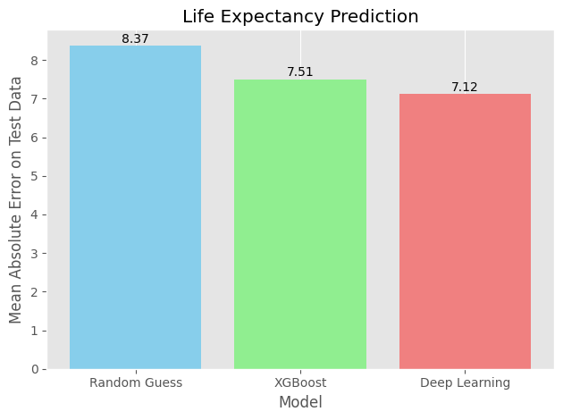

```python
import matplotlib.pyplot as plt

# Apply a style
plt.style.use('ggplot')

# Data
variables = ['Random Guess', 'XGBoost', 'Deep Learning']
values = [mean_test_mae_random_guess, mean_test_mae_xgboost, mean_test_mae_deeplearning]  # Example values

# Colors
colors = ['skyblue', 'lightgreen', 'lightcoral']

# Create bar chart with colors
bars = plt.bar(variables, values, color=colors)

# Display the exact value on top of each bar
for bar in bars:
    yval = bar.get_height()
    plt.text(bar.get_x() + bar.get_width()/2, yval + 0.01, round(yval, 2), ha='center', va='bottom')

# Title and labels
plt.title('Life Expectancy Prediction')
plt.xlabel('Model')
plt.ylabel('Mean Absolute Error on Test Data')

# Add grid (horizontal lines)
plt.grid(axis='y')

# Show plot
plt.tight_layout()  # To ensure that everything fits without overlap
plt.show()
```

```python
predictability_boost=(mean_test_mae_random_guess-mean_test_mae_deeplearning)/mean_test_mae_random_guess*100
print("By using a snapshot of information on participant diet and smoking habits in the deep learning model, predictability of LifeSpan has improved by " + str(round(predictability_boost,2))+ " percent.")
```

```
By using a snapshot of information on participant diet and smoking habits in the deep learning model, predictability of LifeSpan has improved by 14.92 percent.
```

## Conclusion

The findings from this study indicate that possessing a snapshot of an individual's dietary and smoking habits at any point in their life can make their lifespan prediction more accurate by about 15% compared to being uninformed. Regular smoking and a diet rich in carbohydrates are associated with a shortened life, while incorporating salad and wine into one's diet seems to enhance longevity. While diet and smoking habits undeniably play a significant role, they don't capture the entirety of factors affecting human lifespan. However, their impact is undeniably profound. The takeaway? Eat wisely, abstain from smoking, and pave the way for a longer life.